Get the test set and training set. The test set does not have labels as they are the metrics of success in competition that the dataset is for.

```python
import pandas as pd
import numpy as np

# get all the 4327 training emails
X_raw = []
for i in range(4327):
    f = open('CSDMC2010_SPAM/TRAINING/TRAIN_0' + str(i).zfill(4) + '.eml', errors='ignore')
    X_raw.append(f.read())

X_raw = np.array(X_raw)
print('Train set size: {}'.format(len(X_raw)))

# get all the 4327 training email labels
f = open('CSDMC2010_SPAM/SPAMTrainLight.label')
y = np.array(f.read().splitlines()).astype('bool')
print('Train label set size: {}'.format(len(y)))
```

```
Train set size: 4327
Train label set size: 4327
```

# Preprocessing

Tokenize the email:

```python
import nltk
words = nltk.word_tokenize(X_raw[0])
```

Take a look at some of the content:

```python
words[:10]
```

```
['Return-Path',
 ':',
 'ler',
 '@',
 'lerami.lerctr.org',
 'Delivery-Date',
 ':',
 'Fri',
 'Sep',
 '13']
```

Make all lowercase:

```python
[w.lower() for w in words][:10]
```

```
['return-path',
 ':',
 'ler',
 '@',
 'lerami.lerctr.org',
 'delivery-date',
 ':',
 'fri',
 'sep',
 '13']
```

Remove all words/tokens that are only 2 character long:

```python
[w for w in words if len(w) > 2][:10]
```

```
['Return-Path',
 'ler',
 'lerami.lerctr.org',
 'Delivery-Date',
 'Fri',
 'Sep',
 '23:14:55',
 '2002',
 'Return-Path',
 'bengreen']
```

Remove numbers:

```python
[w for w in words if not w.isnumeric()][:10]
```

```
['Return-Path',
 ':',
 'ler',
 '@',
 'lerami.lerctr.org',
 'Delivery-Date',
 ':',
 'Fri',
 'Sep',
 '23:14:55']
```

Combine making words lowercase, removing 2 character long tokens/words and removing numbers:

```python
test = [w.lower() for w in words if len(w) > 2 and not w.isnumeric()]
test[:10]
```

```
['return-path',
 'ler',
 'lerami.lerctr.org',
 'delivery-date',
 'fri',
 'sep',
 '23:14:55',
 'return-path',
 'bengreen',
 'mindupmerchants.com']
```

Do lemmatization (reduce words to root lemma/stem):

```python
test[450:480]
```

```
['whole',
 'thing',
 'was',
 'launched',
 'just',
 'few',
 'weeks',
 'ago',
 'and',
 'more',
 'than',
 'happy',
 'with',
 'earnings',
 'far',
 'must',
 'tell',
 'you',
 'wouldn',
 'able',
 'anything',
 'without',
 'corporate',
 'help',
 'which',
 'was',
 'unusually',
 'thorough',
 'timely',
 'and']
```

```python
porter = nltk.PorterStemmer()
test = [porter.stem(w) for w in test]
test[450:480]
```

```
['whole',
 'thing',
 'wa',
 'launch',
 'just',
 'few',
 'week',
 'ago',
 'and',
 'more',
 'than',
 'happi',
 'with',
 'earn',
 'far',
 'must',
 'tell',
 'you',
 'wouldn',
 'abl',
 'anyth',
 'without',
 'corpor',
 'help',
 'which',
 'wa',
 'unusu',
 'thorough',
 'time',
 'and']
```

Notice that the Porter Stemmer does not not necessarily stem the words correctly, for example 'happi' and 'unusu' are not true stems, but this may not be a problem for our ML application.

Remove stopwords (common words such as 'but', 'your', 'should' and more):

```python
from nltk.corpus import stopwords
stopwords = nltk.corpus.stopwords.words('english')
[w for w in test if w not in stopwords][400:420]
```

```
['keep',
 'free',
 'time',
 'free',
 'good',
 'luck',
 'class=msobodytext',
 "style='text-align",
 'justifi',
 'href=',
 'http',
 '//www.mindupmerchants.com/default.asp',
 'id=5581',
 'http',
 '//www.mindupmerchants.com/default.asp',
 'id=5581',
 'class=msobodytext',
 "style='text-align",
 'justifi',
 'ben']
```

Combine the previous text processing steps to only get lemmas of alphabetic words and strip stopwords:

```python
import nltk
from nltk.corpus import stopwords

f = open('CSDMC2010_SPAM/TESTING/TEST_00000.eml')
words_raw = nltk.word_tokenize(f.read())

porter = nltk.PorterStemmer()
stopwords = nltk.corpus.stopwords.words('english')
words = [porter.stem(w.lower()) for w in words if len(w) > 2 and w.isalpha() and w.lower() not in stopwords]
len(words)
```

```
309
```

```python
from sklearn.feature_extraction.text import CountVectorizer
vectorizer = CountVectorizer()
X = vectorizer.fit_transform([' '.join(words)])
```

```python
vectorizer.get_feature_names()
```

```
['abl',
 'absolut',
 'action',
 'ago',
 'alon',
 'also',
 'anyth',
 'assist',
 'back',
 'battl',
 'ben',
 'bengreen',
 'bill',
 'bodi',
 'bombard',
 'breaker',
 'busi',
 'call',
 'card',
 'cdt',
 'choic',
 'click',
 'consantli',
 'consid',
 'control',
 'corpor',
 'could',
 'daili',
 'date',
 'deal',
 'death',
 'decent',
 'demand',
 'differ',
 'disclos',
 'discov',
 'div',
 'done',
 'earn',
 'effort',
```

[output cut: 150 more lines]

```
 'valuabl',
 'want',
 'wast',
 'way',
 'week',
 'well',
 'whether',
 'whole',
 'without',
 'word',
 'work',
 'worst',
 'ye',
 'yeah',
 'yet']
```

## Vectorize

Transformer for manual text processing (stemming, lowercase, filtering out nonalphabetic and stopwords):

```python
from sklearn.base import BaseEstimator, TransformerMixin
import nltk
from nltk.corpus import stopwords

class TokenPreprocessor(BaseEstimator, TransformerMixin):
    def __init__(self):
        self.stopwords = nltk.corpus.stopwords.words('english')

    def fit(self, X, y=None):
        return self
    def transform(self, X):
        porter = nltk.PorterStemmer()
        X_new = []
        for email in X:
            words = nltk.word_tokenize(email)
            X_new.append(' '.join([porter.stem(w.lower()) for w in words if len(w) > 2 and w.isalpha() and w.lower() not in self.stopwords]))
        return X_new
```

Perform text vectorization:

```python
from sklearn.feature_extraction.text import CountVectorizer

token_preprocessor= TokenPreprocessor()
vectorizer = CountVectorizer()

X = vectorizer.fit_transform(token_preprocessor.fit_transform(X_raw))
```

```python
X.shape
```

```
(4327, 39576)
```

# Train

We hit very good results right off the bat with stochastic gradient descent linear classifier:

```python
from sklearn.linear_model import SGDClassifier
from sklearn.model_selection import cross_val_predict
from sklearn.metrics import confusion_matrix

sgd_clf = SGDClassifier()
y_pred = cross_val_predict(sgd_clf, X, y, cv=3)
confusion_matrix(y, y_pred)
```

```
array([[1335,   43],
       [  39, 2910]], dtype=int64)
```

We can try other alternatives such as random forest classifier but since our results were so good with linear classifier, we will proceed to tweak it isntead.

```python
from sklearn.ensemble import RandomForestClassifier

forest_clf = RandomForestClassifier()
y_pred = cross_val_predict(forest_clf, X, y, cv=3)
confusion_matrix(y, y_pred)
```

```
array([[1323,   55],
       [  56, 2893]], dtype=int64)
```

Searching for best hyperparams:

```python
from scipy.stats import expon
from sklearn.model_selection import RandomizedSearchCV

param_dist = {
    'penalty': ['l2', 'elasticnet', 'l1'],
    'alpha': expon(scale=0.0001),
    'tol': expon(scale=0.001),
}

random_search = RandomizedSearchCV(SGDClassifier(), param_distributions=param_dist, n_iter=100, cv=3)
random_search.fit(X, y)
random_search.best_params_
```

```
{'alpha': 6.190738456788442e-07,
 'penalty': 'elasticnet',
 'tol': 0.0026199154609783128}
```

```python
y_pred = cross_val_predict(random_search.best_estimator_, X, y, cv=3)
confusion_matrix(y, y_pred)
```

```
array([[1338,   40],
       [  84, 2865]], dtype=int64)
```

With a spam filter we may care more about precision than recall so below is a visualization of the tradeoff between precision and recall if we were to attempt to manually tweak the decision score threshold:

```python
y_scores = cross_val_predict(random_search.best_estimator_, X, y, cv=3, method="decision_function")
```

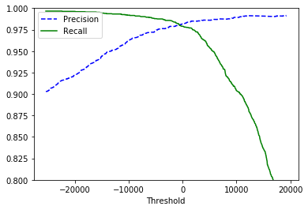

```python
from sklearn.metrics import precision_recall_curve
%matplotlib inline
import matplotlib.pyplot as plt

precisions, recalls, thresholds = precision_recall_curve(y, y_scores)

def plot_precision_recall_vs_threshold(precisions, recalls, thresholds):
    plt.plot(thresholds, precisions[:-1], "b--", label='Precision')
    plt.plot(thresholds, recalls[:-1], "g-", label='Recall')
    plt.xlabel('Threshold')
    plt.legend(loc="upper left")
    plt.ylim([0.8, 1])

plot_precision_recall_vs_threshold(precisions[1000:2001], recalls[1000:2001], thresholds[1000:2000])
plt.show()
```

```python
y_high_precision_pred = (y_scores > 400)
confusion_matrix(y, y_high_precision_pred)
```

```
array([[1326,   52],
       [  65, 2884]], dtype=int64)
```

Here is the default predictions:

```python
y_default_pred = (y_scores > 0)
confusion_matrix(y, y_default_pred)
```

```
array([[1324,   54],
       [  63, 2886]], dtype=int64)
```

Below a more sensible precision recall tradeoff:

```python
y_precision_pred = (y_scores > 100)
confusion_matrix(y, y_precision_pred)
```

```
array([[1324,   54],
       [  63, 2886]], dtype=int64)
```

# Test

Prepare test data:

```python
# get all the 1827 test emails
X_test_raw = []
for i in range(1, 1828):
    f = open('TT-mails/TT/TEST_' + str(i) + '.eml', errors='ignore')
    X_test_raw.append(f.read())

X_test = vectorizer.transform(token_preprocessor.transform(X_test_raw))
print('Test set size: {}'.format(X_test.shape))
```

```
Test set size: (1827, 39576)
```

Predict:

```python
y_test_predictions = random_search.best_estimator_.predict(X_test)
y_test_predictions
```

```
array([ True,  True,  True, ..., False, False, False], dtype=bool)
```

Export solutions to file to be evaluated:

```python
solution = pd.DataFrame(data={'Id': range(1, 1828), 'Prediction': y_test_predictions.astype('int')})
solution.head()
```

|  | Id | Prediction |
| --- | --- | --- |
| 0 | 1 | 1 |
| 1 | 2 | 1 |
| 2 | 3 | 1 |
| 3 | 4 | 0 |
| 4 | 5 | 0 |

```python
file = open('TT_solution.csv', 'w')
solution.to_csv(file, index=False)
file.close()
```

The final score for the submission was 0.99781 out of 1 on Kaggle "ADCG SS14 Challenge 02 - Spam Mails Detection" competition so quite good! The competition ended 4 years ago though so that's too bad.